# Day 1: Exploring Data

## 1. Introduction to R

This file is an **R Markdown** *`document`*. R Markdown documents combine text (with some formatting options), R code, and R outputs including figures. They are a great way to produce self-contained, reproducible, well-documented data analyses.

### a. Basics

Here is an R code chunk with is defined by `{r}`:

```r
# Hashtags are used before text comments to explain what the code is for

# To submit code, put your cursor *anywhere on the line* and do one of the following:
# - hit ctrl+enter for PC or cmd+enter for Mac users
# - click on the play button on the top right of this code chunk
# - click "Run" on the top right of this pane
print("Welcome to R!")
```

```
## [1] "Welcome to R!"
```

We can use R as a calculator:

```r
6*2 # 6 times 2
```

```
## [1] 12
```

```r
6/2 # 6 divided by 2
```

```
## [1] 3
```

```r
6^2 # 6 squared
```

```
## [1] 36
```

```r
##### Try it! #####
# Multiply 6 by all previous whole numbers (this is called the factorial of 6)
6*5*4*3*2*1
```

```
## [1] 720
```

But luckily there are some built-in functions (called base R):

```r
# Base R comes with many built-in functions:
factorial(6)
```

```
## [1] 720
```

```r
##### Try it! #####
# What should we expect for log(100)? What does R give us?
log(100)
```

```
## [1] 4.60517
```

To learn more about specific functions, R has a great documentation within R Studio but also online:

```r
# Put a `?` in front of the function name to pull documentation in the Output pane
?log

##### Try it! #####
# In the documentation you can read about the function that computes log base 10.
# What is log base 10 of 100?
log10(100)
```

### b. Types of objects

The pane in the top right is the **Environment**. This is where objects we work with (like datasets) are saved! The notation `<-` is an assignment operator:

```r
# Let's create some objects
species <- "Adelie"
flipper_length_mm <- 180
is_male <- TRUE

# What type of object is each one?
class(species)
```

```
## [1] "character"
```

```r
class(flipper_length_mm)
```

```
## [1] "numeric"
```

```r
class(is_male)
```

```
## [1] "logical"
```

Beyond just having an observation, we can consider vectors/variables which we can manipulate:

```r
# Now store multiple values in these objects using a vector with c()
species <- c("Adelie", "Chinstrap", "Gentoo", "Adelie")
flipper_length_mm <- c(180, 195, 210, 175)
is_male <- c(TRUE, FALSE, TRUE, FALSE)

# Summary operations on numeric vectors
sum(flipper_length_mm)
```

```
## [1] 760
```

```r
length(flipper_length_mm)
```

```
## [1] 4
```

```r
##### Try it! #####
# What is the mean flipper length?
mean(flipper_length_mm)
```

```
## [1] 190
```

More importantly, we will manipulate datasets usually in the form of **dataframes**:

```r
# Build a small data frame from scratch
penguin_data <- data.frame(
  species = c("Adelie", "Chinstrap", "Gentoo", "Adelie"),
  flipper_length_mm = c(180, 195, 210, 175),
  is_male = c(TRUE, FALSE, TRUE, FALSE))

# Take a look at the whole data
penguin_data
```

```
##     species flipper_length_mm is_male
## 1    Adelie               180    TRUE
## 2 Chinstrap               195   FALSE
## 3    Gentoo               210    TRUE
## 4    Adelie               175   FALSE
```

```r
# Rows = individual penguins, Columns = variables measured
str(penguin_data)
```

```
## 'data.frame':    4 obs. of  3 variables:
##  $ species          : chr  "Adelie" "Chinstrap" "Gentoo" "Adelie"
##  $ flipper_length_mm: num  180 195 210 175
##  $ is_male          : logi  TRUE FALSE TRUE FALSE
```

```r
# Access one variable at a time
penguin_data$flipper_length_mm
```

```
## [1] 180 195 210 175
```

```r
##### Try it! #####
# Calculate the mean flipper length in this dataframe
```

We will learn more ways to summarize variables!

### c. Packages

Sometimes base R is not enough! R packages are collections of functions and datasets developed by the R community worldwide. You can install a package by typing the function `install.packages(“package_name”)` **in the console** pane.

For example, install the package `tidyverse` (it should already be installed on the server) which is THE reference for manipulating data:

```r
# Install the package
install.packages("tidyverse")
```

Once a package is installed, you need to load the package to call specific functions from this package using `library(package_name)`:

```r
# Load the package
library(tidyverse)
```

Highly recommend this textbook to learn how to use [R for Data Science](https://r4ds.hadley.nz/).

Another package we will use today is `palmerpenguins` which contains a famous dataset:

```r
# Install the package containing the dataset
install.packages("palmerpenguins")

# Read the documentation
?palmerpenguins::penguins
```

```r
# Load the package
library(palmerpenguins)

# Save a copy of the dataset in your environment as a dataframe
my_penguins <- as.data.frame(penguins)
```

## 2. Exploring Data

When we start exploring data, we should learn about the source and context of the dataset.

#### **Try it! Identify the following information about the dataset:**

- **Study design:** observational study
- **Population:** penguins in Palmer Archipelago
- **Sample:** penguins in the dataset / have measurements for
- **Number of sampling units:** 344 penguins
- **Number of variables:** 8 variables

```r
# Check the structure of the dataset
str(my_penguins)
```

```
## 'data.frame':    344 obs. of  8 variables:
##  $ species          : Factor w/ 3 levels "Adelie","Chinstrap",..: 1 1 1 1 1 1 1 1 1 1 ...
##  $ island           : Factor w/ 3 levels "Biscoe","Dream",..: 3 3 3 3 3 3 3 3 3 3 ...
##  $ bill_length_mm   : num  39.1 39.5 40.3 NA 36.7 39.3 38.9 39.2 34.1 42 ...
##  $ bill_depth_mm    : num  18.7 17.4 18 NA 19.3 20.6 17.8 19.6 18.1 20.2 ...
##  $ flipper_length_mm: int  181 186 195 NA 193 190 181 195 193 190 ...
##  $ body_mass_g      : int  3750 3800 3250 NA 3450 3650 3625 4675 3475 4250 ...
##  $ sex              : Factor w/ 2 levels "female","male": 2 1 1 NA 1 2 1 2 NA NA ...
##  $ year             : int  2007 2007 2007 2007 2007 2007 2007 2007 2007 2007 ...
```

When provided, it is very important to read the documentation to understand how the variables were measured (which unit). For example, in the documentation, we learn that there are 3 species of penguins:

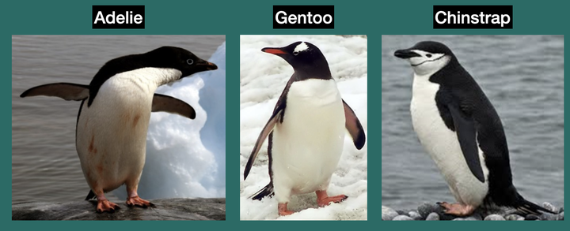

To guide our exploration, we formulate research questions. For example:

- Are there any differences between the three species of penguins? (this question is a little vague)
- Are there any differences between the three species of penguins in terms of their flipper length? (this question is more specific)
- **Write your own**: Do male and female penguins differ in their body mass?

Our research question will determine how to analyze our data, which variables are involved, and which statistical model we should consider.

### a. Describing 1 categorical variable

When describing categorical variables, we pay attention to which category are the most/least common. We can visualize a single categorical variable with a bar plot:

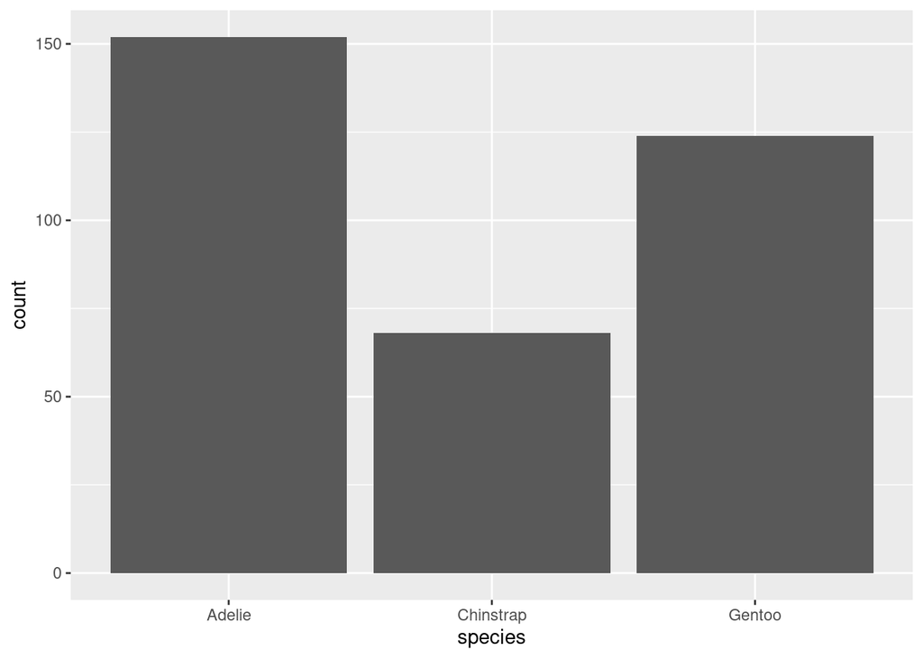

```r
my_penguins |>
  # Make a plot
  ggplot() +
  # Use geom_bar and define mapping aesthetics
  geom_bar(aes(x = species))
```

We include counts (frequencies) or proportions (relative frequencies) as summary statistics:

```r
my_penguins |>
  # Report counts for each group
  count(species) |>
  # Calculate proportions
  mutate(proportion = n/sum(n))
```

```
##     species   n proportion
## 1    Adelie 152  0.4418605
## 2 Chinstrap  68  0.1976744
## 3    Gentoo 124  0.3604651
```

### b. Describing 1 numeric variable

When describing numeric variables, we pay attention to what a typical value is (center) and how the values vary from each other (spread), where values are most common and where values are rare (shape).

Since we can have a wide range of different values, especially for continuous variables, it does not necessarily make sense to visualize what *exact value* is the most common but rather focus on what *range of values* is the most common using a histogram:

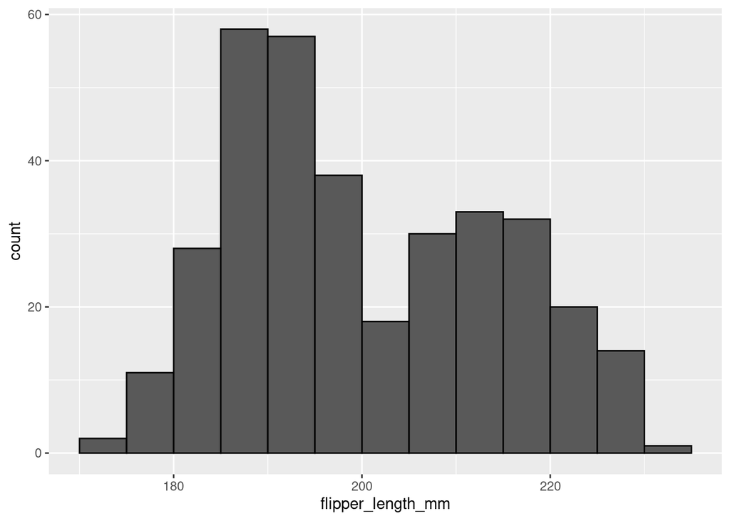

```r
my_penguins |>
  # Make a plot
  ggplot() +
  # Use geom_histogram and define mapping aesthetics
  geom_histogram(aes(x = flipper_length_mm),
                 # Set bin width and center
                 binwidth = 5, center = 2.5, color = "black")
```

#### **Try it! Play around with the values for binwidth and center. Notice how the shape of the histogram changes depending on how we define the bins?**

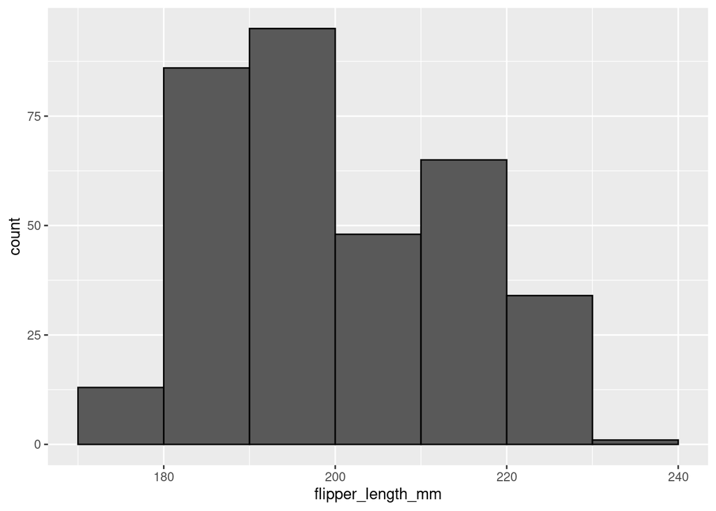

```r
# Type any code here
my_penguins |>
  # Make a plot
  ggplot() +
  # Use geom_histogram and define mapping aesthetics
  geom_histogram(aes(x = flipper_length_mm),
                 # Set bin width and center
                 binwidth = 10, center = 5, color = "black")
```

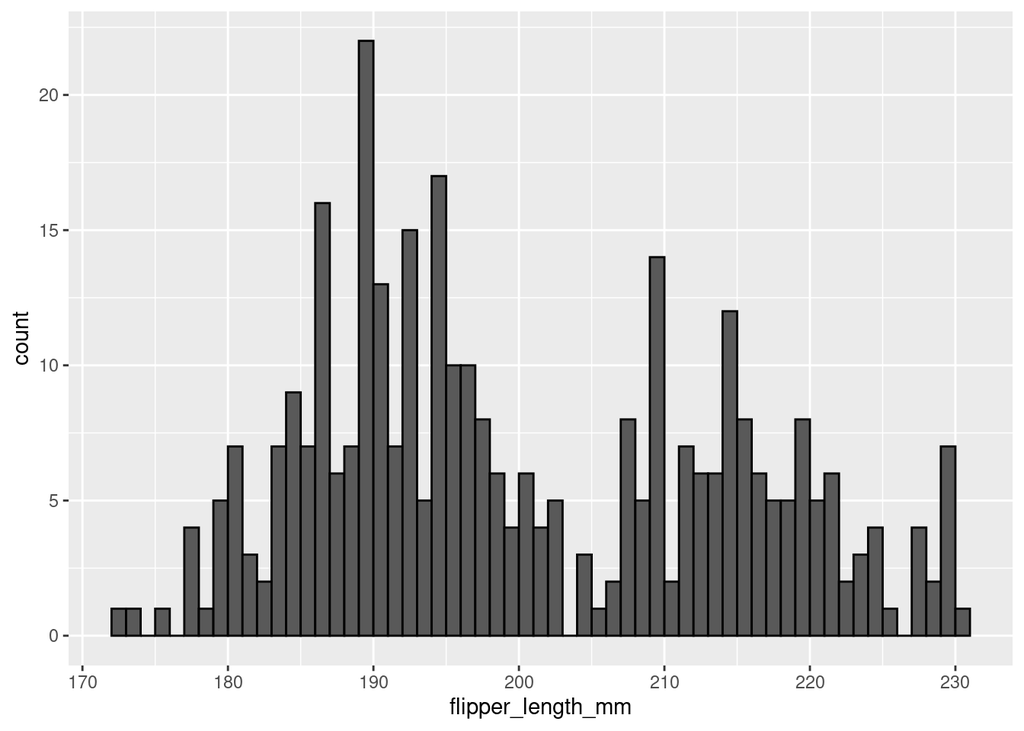

```r
my_penguins |>
  # Make a plot
  ggplot() +
  # Use geom_histogram and define mapping aesthetics
  geom_histogram(aes(x = flipper_length_mm),
                 # Set bin width and center
                 binwidth = 1, center = 0.5, color = "black")
```

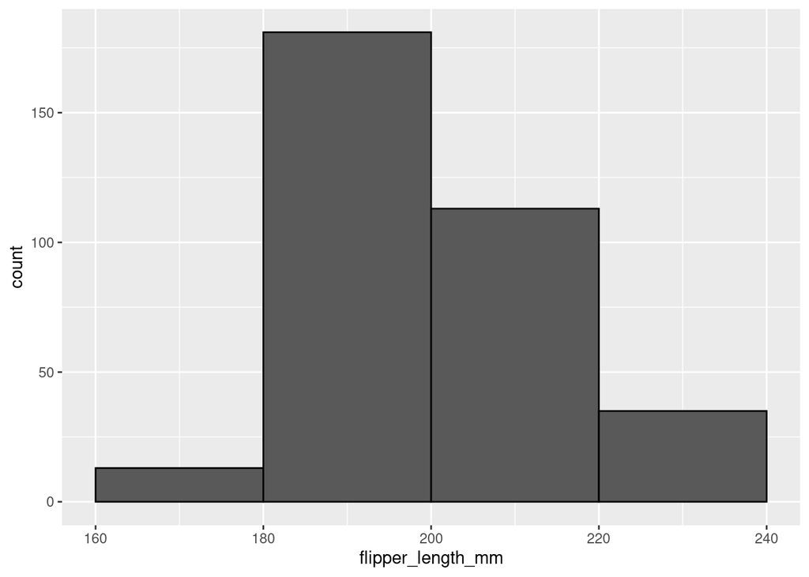

```r
my_penguins |>
  # Make a plot
  ggplot() +
  # Use geom_histogram and define mapping aesthetics
  geom_histogram(aes(x = flipper_length_mm),
                 # Set bin width and center
                 binwidth = 20, center = 10, color = "black")
```

We report values of center (mean or median) and spread (standard deviation or IQR) as summary statistics:

```r
my_penguins |>
  # Summary statistics
  summarize(
    mean = mean(flipper_length_mm, na.rm = TRUE),
    median = median(flipper_length_mm, na.rm = TRUE),
    sd = sd(flipper_length_mm, na.rm = TRUE),
    IQR = IQR(flipper_length_mm, na.rm = TRUE),
    min_mass = min(flipper_length_mm, na.rm = TRUE),
    max_mass = max(flipper_length_mm, na.rm = TRUE))
```

```
##       mean median       sd IQR min_mass max_mass
## 1 200.9152    197 14.06171  23      172      231
```

Another common graph for numeric variables is a boxplot which represents the 5-number summary of a variable: minimum, first quartile, median, third quartile, maximum (delimiting the lower point of the whisker, the lower bar of the box, the solid bar in the box, the upper bar of the box, and the upper point of the whisker, respectively):

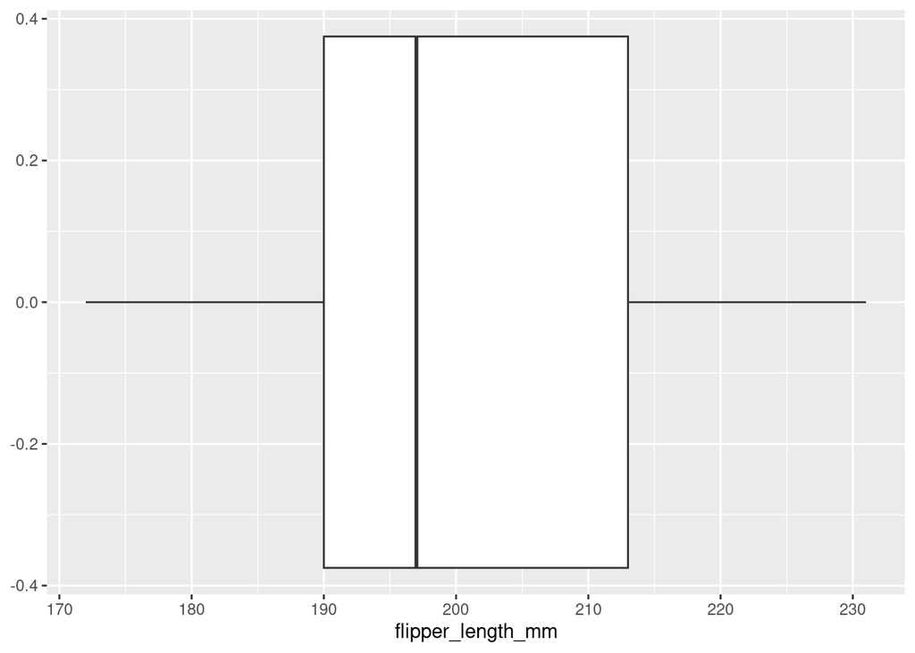

```r
my_penguins |>
  # Make a plot
  ggplot() +
  # Use geom_boxplot and define mapping aesthetics
  geom_boxplot(aes(x = flipper_length_mm))
```

Boxplots sometimes summarize the data too much (just into five numbers) and we might miss important characteristics of the data. What information are we missing compared to what we could see in the histogram?

Sometimes, we use density plots to display the “smooth” distribution of a numeric variable:

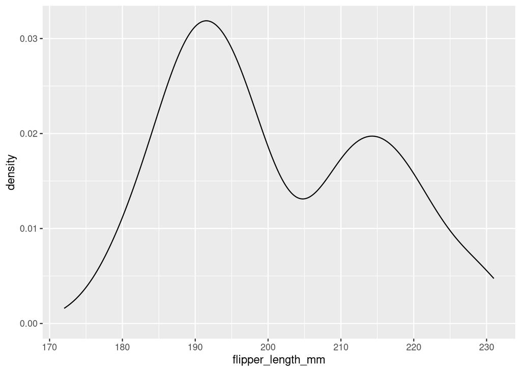

```r
my_penguins |>
  # Make a plot
  ggplot() +
  # Use geom_density and define mapping aesthetics
  geom_density(aes(x = flipper_length_mm))
```

### c. Describing 1 numeric and 1 categorical variable

When comparing a numeric variable across categories, we may wonder if the distribution of the numeric variable (center, spread, shape) is about the same across all categories or not.

The most convenient way (using R) to compare the distribution of a numeric variable across categories is to use grouped boxplots:

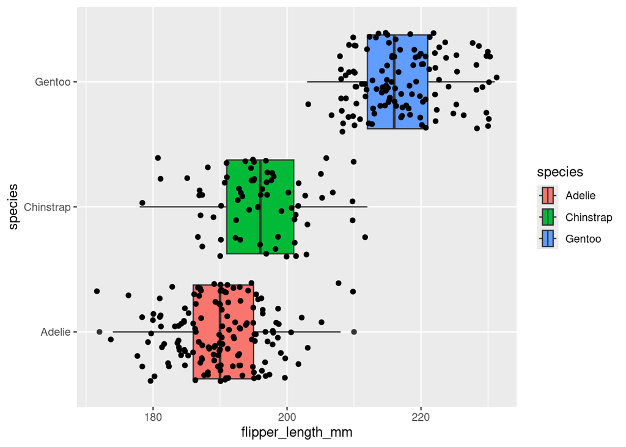

```r
my_penguins |>
  # Make a plot
  ggplot() +
  # Use geom_boxplot and define mapping aesthetics: x = predictor, y = outcome
  geom_boxplot(aes(x = flipper_length_mm, y = species, fill = species)) +
  # Add the data
  geom_jitter(aes(x = flipper_length_mm, y = species))
```

To compare histograms, we use what we call faceting:

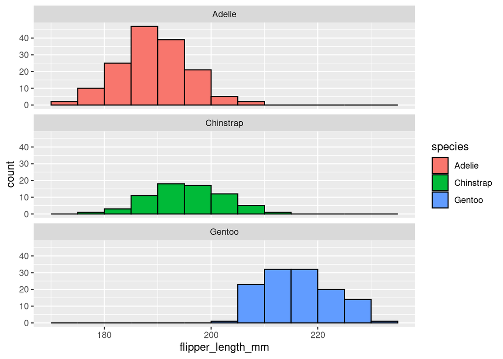

```r
my_penguins |>
  # Make a plot
  ggplot() +
  # Use geom_histogram and define mapping aesthetics, x = response
  geom_histogram(aes(x = flipper_length_mm, fill = species),
                 # Set bin width and center
                 binwidth = 5, center = 2.5, color = "black") +
  # Facet per category
  facet_wrap(~species, ncol = 1)
```

We report summary statistics for each species:

```r
my_penguins |>
  # Split the data in groups
  group_by(species) |>
  # Summary statistics
  summarize(
    mean = mean(flipper_length_mm),
    median = median(flipper_length_mm, na.rm = TRUE),
    sd = sd(flipper_length_mm, na.rm = TRUE),
    IQR = IQR(flipper_length_mm, na.rm = TRUE),
    min_mass = min(flipper_length_mm, na.rm = TRUE),
    max_mass = max(flipper_length_mm, na.rm = TRUE))
```

```
## # A tibble: 3 × 7
##   species    mean median    sd   IQR min_mass max_mass
##   <fct>     <dbl>  <dbl> <dbl> <dbl>    <int>    <int>
## 1 Adelie      NA     190  6.54     9      172      210
## 2 Chinstrap  196.    196  7.13    10      178      212
## 3 Gentoo      NA     216  6.48     9      203      231
```

### d. Describing 2 numeric variables

The relationship between two numeric variables is typically displayed using a scatterplot:

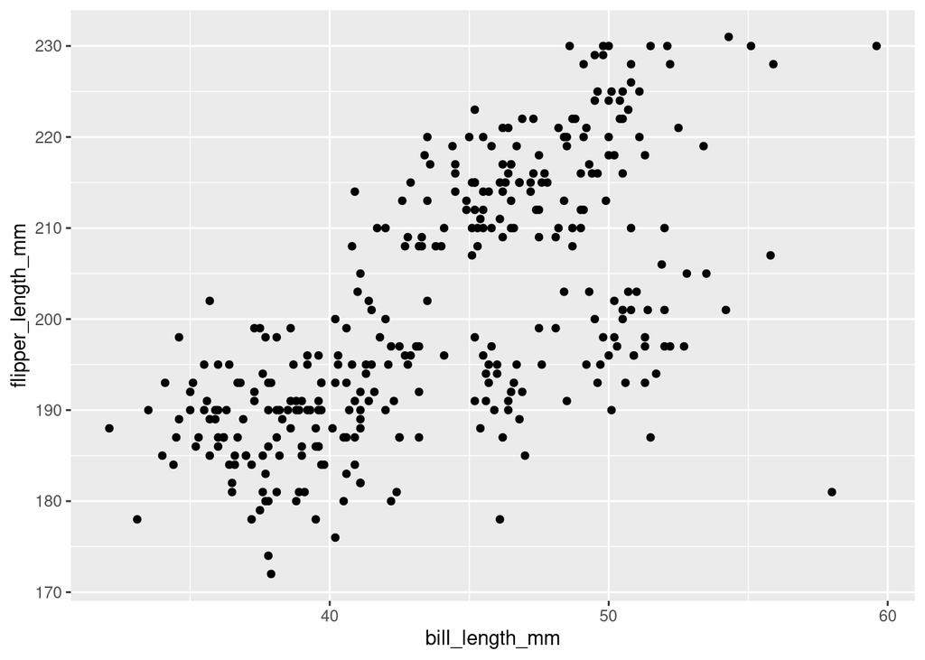

```r
my_penguins |>
  # Make a plot
  ggplot() +
  # Use geom_point and define mapping aesthetics: x = explanatory, y = response
  geom_point(aes(x = bill_length_mm, y = flipper_length_mm))
```

Correlation describes the strength of a (linear) relationship between two variables. With the function `cor`, we refer by default to the Pearson correlation coefficient which takes values between -1 (strong negative correlation) and 1 (strong positive correlation) with 0 indicating that there is no correlation:

```r
my_penguins |>
  # Summary statistics
  summarize(correlation = cor(bill_length_mm, flipper_length_mm, use = "pairwise.complete.obs"))
```

```
##   correlation
## 1   0.6561813
```

### e. Describing 2 categorical variables

We can display the relative distribution at each level with a segmented bar plot:

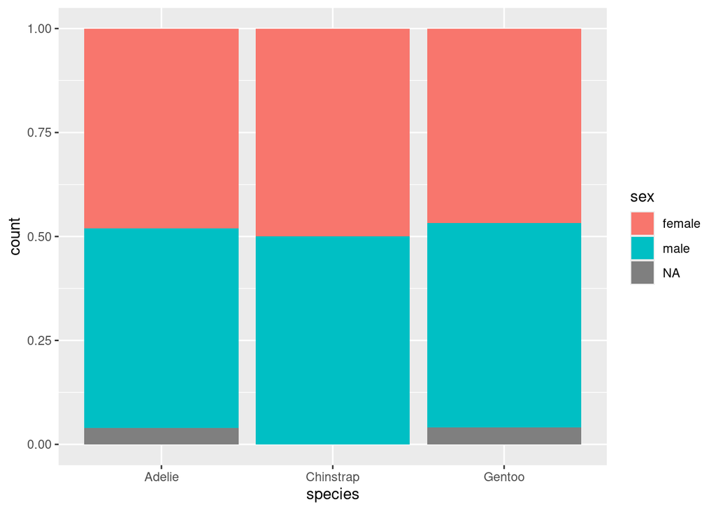

```r
my_penguins |>
  # Make a plot
  ggplot() +
  # Use geom_bar and define mapping aesthetics with fill
  geom_bar(aes(x = species, fill = sex), position = "fill")
```

#### **Try it! Swap the variables for `x =` and `fill =`. Does the graph look any different? Note that the default label for the y-axis is count. But what does it represent?**

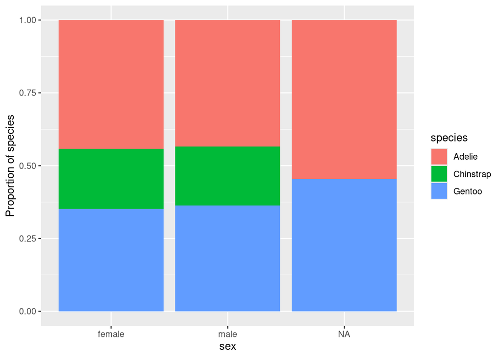

```r
# Type any code here
my_penguins |>
  # Make a plot
  ggplot() +
  # Use geom_bar and define mapping aesthetics with fill
  geom_bar(aes(x = sex, fill = species), position = "fill") +
  # Adjust label on y-axis
  labs(y = "Proportion of species")
```

We can report counts for each pair of groups:

```r
my_penguins |>
  # Report counts for each pair of groups
  count(species, sex) |>
  pivot_wider(names_from = sex, values_from = n, values_fill = 0)
```

```
## # A tibble: 3 × 4
##   species   female  male  `NA`
##   <fct>      <int> <int> <int>
## 1 Adelie        73    73     6
## 2 Chinstrap     34    34     0
## 3 Gentoo        58    61     5
```

But there are two ways to report proportions:

```r
my_penguins |>
  # Report counts for each pair of groups
  count(species, sex) |>
  # Split by one group
  group_by(species) |>
  # Calculate proportions
  mutate(prop = n / sum(n)) |>
  # Reshape results
  select(-n) |>
  pivot_wider(names_from = sex, values_from = prop, values_fill = 0)
```

```
## # A tibble: 3 × 4
## # Groups:   species [3]
##   species   female  male   `NA`
##   <fct>      <dbl> <dbl>  <dbl>
## 1 Adelie     0.480 0.480 0.0395
## 2 Chinstrap  0.5   0.5   0
## 3 Gentoo     0.468 0.492 0.0403
```

```r
my_penguins |>
  # Report counts for each pair of groups
  count(species, sex) |>
  # Split by one group
  group_by(sex) |>
  # Calculate proportions
  mutate(prop = n / sum(n)) |>
  # Reshape results
  select(-n) |>
  pivot_wider(names_from = species, values_from = prop, values_fill = 0)
```

```
## # A tibble: 3 × 4
## # Groups:   sex [3]
##   sex    Adelie Chinstrap Gentoo
##   <fct>   <dbl>     <dbl>  <dbl>
## 1 female  0.442     0.206  0.352
## 2 male    0.435     0.202  0.363
## 3 <NA>    0.545     0      0.455
```

What’s the difference between the two tables above?

### f. Describing more than two variables

Visualizing relationships between more than two variables can be challenging, but it’s possible by incorporating additional visual elements. Some common strategies include:

- Color: Differentiate categories or represent continuous variables through color gradients.
- Facet: Recreate the same plot for different categories of one variable.
- Size: Vary the size of points to indicate another numeric variable.
- Shape: Use different shapes to represent categories, though this works best with a limited number of categories.
- Alpha (Transparency): Adjust transparency to handle overlapping data points.

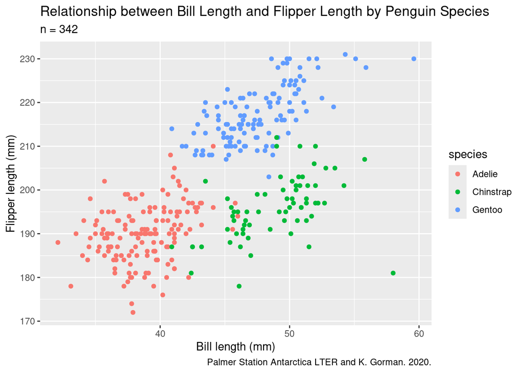

```r
my_penguins |>
  # Make a plot
  ggplot() +
  # Use geom_point and define mapping aesthetics: x = explanatory, y = response
  geom_point(aes(x = bill_length_mm, y = flipper_length_mm, color = species)) +
  # Adding labels
  labs(title = "Relationship between Bill Length and Flipper Length by Penguin Species",
       subtitle = "n = 342",
       x = "Bill length (mm)",
       y = "Flipper length (mm)",
       caption = "Palmer Station Antarctica LTER and K. Gorman. 2020.")
```

#### **Try it! Investigate the following question using a visualization and summary statistics: Do female and male penguins differ in their body mass?**

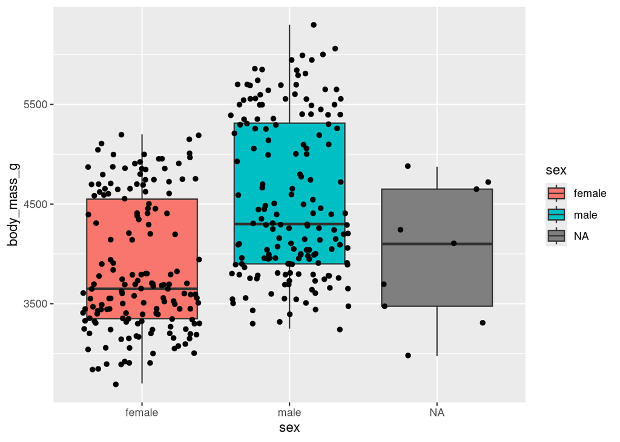

```r
# Type any code here
my_penguins |>
  # Make a plot
  ggplot() +
  # Use geom_boxplot and define mapping aesthetics: x = predictor, y = outcome
  geom_boxplot(aes(x = sex, y = body_mass_g, fill = sex)) +
  # Add the data
  geom_jitter(aes(x = sex, y = body_mass_g))
```

Male penguins tend to have higher body mass than females on average: the distribution of male body mass is shifted higher overall, however, this is some overlap.

## 3. Introduction to Hypothesis Testing

Let’s explore this research question:

> Do female and male penguins differ in their body mass?

First of all, we can only learn from complete observations so we remove any missing values for the variables of interest:

```r
# Save a new version of this dataset, removing missing values
penguins_clean <- my_penguins |>
  # Filter missing values
  filter(!is.na(sex), !is.na(body_mass_g))
```

### a. Calculate observed difference

We calculate the observed difference in mean body mass between the two groups in our sample:

```r
penguins_clean |>
  # For each group
  group_by(sex) |>
  # Summarize data with the mean
  summarize(mean_mass = mean(body_mass_g)) |>
  # Find the difference between means
  summarize(diff = diff(mean_mass)) |>
  # Only keep this value
  pull(diff)
```

```
## [1] 683.4118
```

We observe a difference!

### b. Build a null distribution

Now we wonder: Could this observed difference have happened just by chance?

To answer that, we simulate what would happen if sex had no real effect on body mass: in other words, if the difference we observed was due only to random sampling. We do this by randomly shuffling the sex labels across all the penguins:

```r
penguins_clean |>
  # Shuffle sex
  mutate(shuffled_sex = sample(sex)) |>
  # Focus on variables of interest
  select(body_mass_g, sex, shuffled_sex) |>
  # Only look at first 10 rows
  head(10)
```

```
##    body_mass_g    sex shuffled_sex
## 1         3750   male         male
## 2         3800 female         male
## 3         3250 female       female
## 4         3450 female         male
## 5         3650   male         male
## 6         3625 female       female
## 7         4675   male         male
## 8         3200 female       female
## 9         3800   male       female
## 10        4400   male       female
```

Then we re-calculate the difference after shuffling:

```r
penguins_clean |>
  # Shuffle sex
  mutate(shuffled_sex = sample(sex)) |>
  # For each group
  group_by(shuffled_sex) |>
  # Summarize data with the mean
  summarize(mean_mass = mean(body_mass_g)) |>
  # Find the difference between means
  summarize(diff = diff(mean_mass)) |>
  # Only keep this value
  pull(diff)
```

```
## [1] -5.232684
```

Now the difference is very small!

Let’s repeat that process many times (1,000 times) to build what we call a null distribution of differences we would expect just by chance:

```r
# For reproducibility
set.seed(3)

# Create a dataframe with 1,000 differences
repeated_diffs <- data.frame(
  # Repeat process 1,000 times
  diff = replicate(1000, {
    penguins_clean |>
    # Shuffle sex
    mutate(shuffled_sex = sample(sex)) |>
    # For each group
    group_by(shuffled_sex) |>
    # Summarize data with the mean
    summarize(mean_mass = mean(body_mass_g)) |>
    # Find the difference between means
    summarize(diff = diff(mean_mass)) |>
    # Only keep this value
    pull(diff)
}))
```

Each time we randomly reassign the sex labels, we are simulating what body mass differences might look like if there were no actual difference in body mass between male/female penguins. The result is a distribution of differences that could happen just by chance:

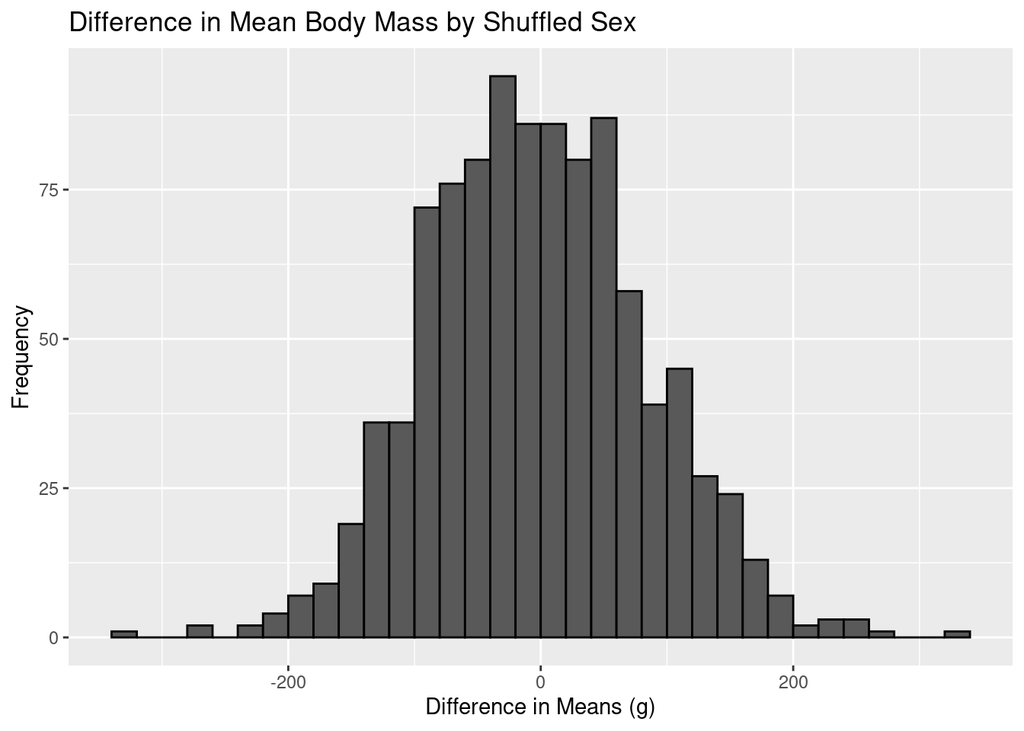

```r
repeated_diffs |>
  # Make a plot
  ggplot() +
  # Histogram with differences
  geom_histogram(aes(x = diff), binwidth = 20, center = 10, color = "black") +
  # Labels
  labs(title = "Difference in Mean Body Mass by Shuffled Sex",
       x = "Difference in Means (g)", y = "Frequency")
```

### c. Compare observed difference to null distribution

Now, how does the observed difference in our sample compare to this null distribution?

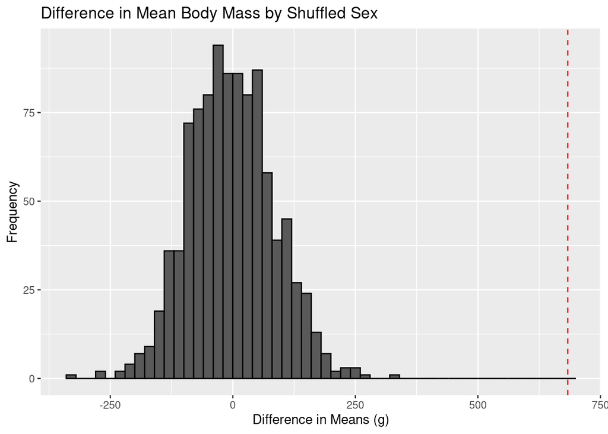

```r
# Histogram with observed value
repeated_diffs |>
  # Make a plot
  ggplot() +
  # Histogram with differences
  geom_histogram(aes(x = diff), binwidth = 20, center = 10, color = "black") +
  # Represent the observed difference
  geom_vline(xintercept = 683.4118, color = "red", linetype = "dashed") +
  # Labels
  labs(title = "Difference in Mean Body Mass by Shuffled Sex",
       x = "Difference in Means (g)", y = "Frequency")
```

### d. Find p-value

Finally, let’s calculate the p-value, which tells us how extreme our observed difference is compared to the null distribution: it is the proportion of simulated differences that were as extreme or more extreme than what we observed.

```r
# Estimate p-value
mean(abs(repeated_diffs$diff) >= 683.4118)
```

```
## [1] 0
```

None!

A small p-value suggests that such a difference would be unlikely to occur by chance alone.

## Recommended Resources

1. [R for Data Science](https://r4ds.hadley.nz/)
2. [Introductory Statistics in R](https://tjfisher19.github.io/introStatModeling/introductory-statistics-in-r.html)